# Transformations

Tutorial 5: exercises and solutions

Dr Massimiliano Canzi

## Setup

```r
library(tidyverse)
library(broom)
library(simling)
```

## The data

`vocabulary_growth` comes from a simulated study of 80 toddlers. Every two months, from 16 to 30 months, their parents ticked the words their child could say on a checklist of 680 words. Before the study, a day-long recording measured how much speech each child hears at home: `input` is the number of adult words per hour. Today we use only the session at 24 months:

```r
v24 <- vocabulary_growth |>
  filter(age == 24)
glimpse(v24)
```

```
Rows: 76
Columns: 4
$ child      <fct> C01, C02, C03, C04, C05, C06, C07, C08, C10, C11,…
$ input      <int> 861, 1252, 544, 893, 927, 1270, 1620, 1324, 1237,…
$ age        <int> 24, 24, 24, 24, 24, 24, 24, 24, 24, 24, 24, 24, 2…
$ vocabulary <int> 267, 373, 122, 320, 227, 590, 182, 319, 407, 175,…
```

Today’s question: do children who hear more speech say more words?

# 1. Centring

## 1.1 A scatterplot

Plot `vocabulary` against `input`, with `input` on the `x` axis and both axes labelled in words. Do children who hear more speech say more words?

## 1.1 Solution

```r
v24 |>
  ggplot(aes(x = input, y = vocabulary)) +
  geom_point(colour = "plum2", size = 3) +
  xlab("Input (adult words per hour)") + ylab("Vocabulary (words)")
```

## 1.1 Solution

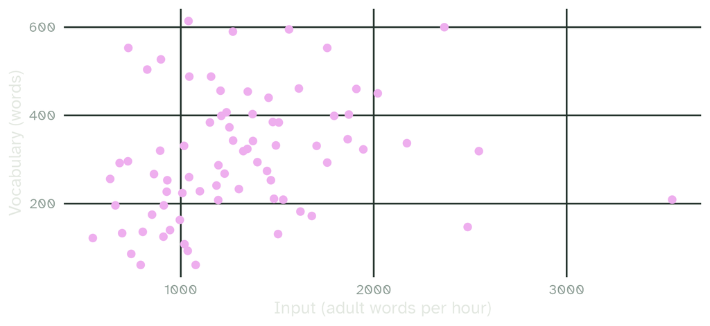

There is a weak upward trend. Most children hear between 500 and 2000 words per hour, and a few hear much more.

## 1.2 Fit a line

Fit a linear model of `vocabulary` as a function of `input` and print its coefficients. The slope is in words per adult word per hour, which is hard to imagine: how many more words does the model predict for a child who hears 100 more words per hour? And what does the intercept mean?

## 1.2 Solution

```r
m <- lm(vocabulary ~ input, data = v24)
coef(m)
```

```
 (Intercept)        input
231.35067737   0.05866986
```

```r
100 * coef(m)["input"]
```

```
   input
5.866986
```

100 more adult words per hour go with about 6 more words in the child’s vocabulary.

The intercept, 231 words, is the prediction for a child who hears no speech at all. No child in the data is anywhere near that: the lowest input is 544 words per hour.

## 1.3 Centre the predictor

Centre `input` on 1200 words per hour, about the median of the data: make a new column `input_c` that is `input` minus 1200. Fit the model again with `input_c`. Which coefficient changes, and what does it mean now?

## 1.3 Solution

```r
v24 <- v24 |>
  mutate(input_c = input - 1200)
m_c <- lm(vocabulary ~ input_c, data = v24)
coef(m_c)
```

```
 (Intercept)      input_c
301.75450998   0.05866986
```

The slope stays the same. The intercept, 302 words, is now the predicted vocabulary of a child who hears 1200 words per hour, a typical child in the data.

# 2. Logarithms

## 2.1 A skewed predictor

Make a histogram of `input`. Then make a second histogram of `log2(input)`. How do the shapes differ?

## 2.1 Solution

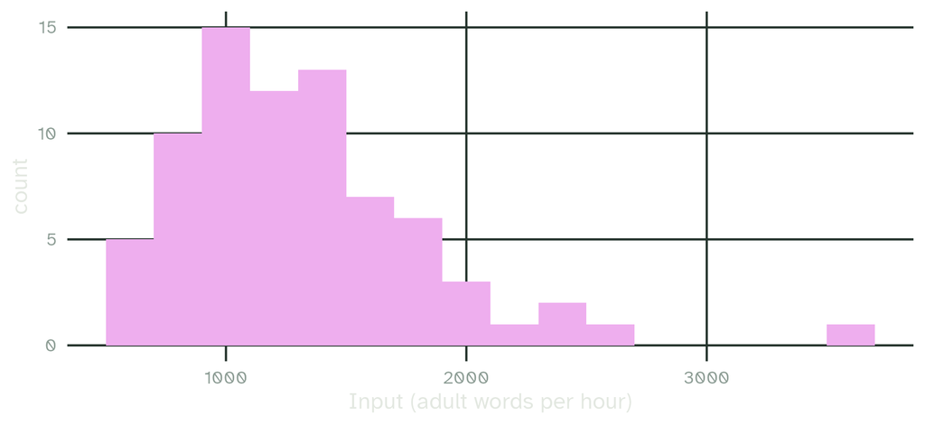

```r
v24 |>
  ggplot(aes(x = input)) +
  geom_histogram(binwidth = 200, fill = "plum2") +
  xlab("Input (adult words per hour)")
```

## 2.1 Solution

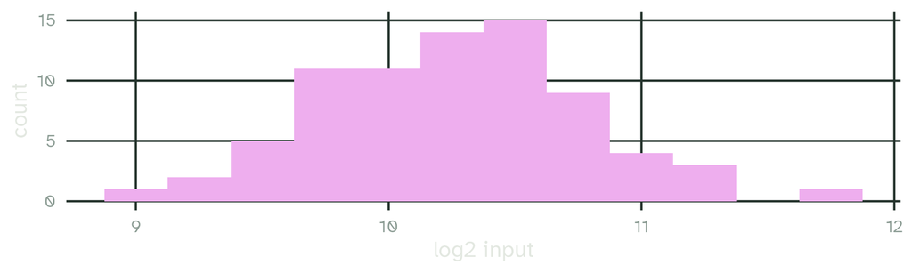

```r
v24 |>
  ggplot(aes(x = log2(input))) +
  geom_histogram(binwidth = 0.25, fill = "plum2") +
  xlab("log2 input")
```

`input` is skewed to the right: most children hear between 500 and 2000 words per hour, and a few hear far more. On the log scale, the distribution is much more symmetrical.

## 2.2 A model on the log scale

Fit a model of `vocabulary` as a function of `log2(input)` and print its coefficients. One step on the `log2` scale is a doubling of the input. Complete the sentence: “Each time the input doubles, the vocabulary grows by ___ words.”

## 2.2 Solution

```r
m_log <- lm(vocabulary ~ log2(input), data = v24)
coef(m_log)
```

```
(Intercept) log2(input)
 -453.91973    74.26849
```

Each time the input doubles, the vocabulary grows by about 74 words.

## 2.3 Doubling the input

Use `predict()` to get the predicted vocabulary for children who hear 600, 1200 and 2400 words per hour. How large is the step from 600 to 1200, and from 1200 to 2400?

## 2.3 Solution

```r
pred <- predict(m_log, newdata = tibble(input = c(600, 1200, 2400)))
pred
```

```
       1        2        3
231.4907 305.7592 380.0277
```

```r
diff(pred)
```

```
       2        3
74.26849 74.26849
```

Both steps are 74 words, the slope of `m_log`. On the log scale, every doubling adds the same amount, whether a child goes from 600 to 1200 words per hour or from 1200 to 2400.

## 2.4 Which model fits better?

Compare `R²` of `m` and `m_log` with `glance()`.

## 2.4 Solution

```r
glance(m)$r.squared
```

```
[1] 0.04577737
```

```r
glance(m_log)$r.squared
```

```
[1] 0.07649407
```

`m_log` fits a little better (8% against 5% of the variance). Both numbers are small: children differ in many ways besides how much speech they hear.

# 3. Standardising and correlation

## 3.1 Correlation

Use `cor()` to compute the correlation between `vocabulary` and `input`, and between `vocabulary` and `log2(input)`.

## 3.1 Solution

```r
cor(v24$vocabulary, v24$input)
```

```
[1] 0.2139565
```

```r
cor(v24$vocabulary, log2(v24$input))
```

```
[1] 0.2765756
```

Both correlations are weak and positive, and the one with the log input is a little stronger.

## 3.2 Standardise both variables

Add two columns with z-scores: `vocabulary_z`, the standardised vocabulary, and `log_input_z`, the standardised `log2(input)`. Wrap `scale()` in `as.numeric()`, because `scale()` returns a matrix. Fit a model of `vocabulary_z` as a function of `log_input_z`. Which number from 3.1 is the slope?

## 3.2 Solution

```r
v24 <- v24 |>
  mutate(vocabulary_z = as.numeric(scale(vocabulary)),
         log_input_z = as.numeric(scale(log2(input))))
coef(lm(vocabulary_z ~ log_input_z, data = v24))
```

```
 (Intercept)  log_input_z
7.617638e-16 2.765756e-01
```

The slope is the correlation between `vocabulary` and `log2(input)`, 0.28: one standard deviation more log input goes with 0.28 standard deviations more vocabulary. The intercept is 0, because both variables have a mean of 0.

## 3.3 Bonus: centre on the log scale

The intercept of `m_log` is the predicted vocabulary for a child who hears one word per hour, because `log2(1)` is 0. Centre the log input on `log2(1200)` and fit the model again. What does the intercept mean now?

## 3.3 Solution

```r
v24 <- v24 |>
  mutate(log_input_c = log2(input) - log2(1200))
coef(lm(vocabulary ~ log_input_c, data = v24))
```

```
(Intercept) log_input_c
  305.75922    74.26849
```

The intercept is the predicted vocabulary of a child who hears 1200 words per hour. Centring works on the log scale just as it does on the original one.

## 3.4 Bonus: the true model

`?vocabulary_growth` gives the model the data were simulated from. In it, doubling the input moves the steep middle part of each child’s growth curve two months earlier. Why does that make a model with `log2(input)` a better choice than one with `input`?

## 3.4 Solution

In the true model, input acts on the log2 scale: going from 600 to 1200 words per hour helps as much as going from 1200 to 2400. A model with `log2(input)` makes the same assumption, while a model with `input` assumes that every extra word per hour helps equally.

## Reading

This tutorial goes with chapter 5 of Winter (2019).

Winter, B. (2019). *Statistics for linguists: An introduction using R*. Routledge. https://doi.org/10.4324/9781315165547

## Slides and exercises

[figure not shown]

These slides

mcanzi.de/statistics/tutorials/05_transformations.html

Exercise sheet (R Markdown)

mcanzi.de/statistics/tutorials/05_transformations.Rmd